# FML Project - Krishna Kumar Tavva - 811283461

2023-05-07

#Loading Required Packages

```r
library("readr")
library("dplyr")
library("ISLR")
library("caret")
library("class")
library("ggplot2")
library("FactoMineR")
library("ggcorrplot")
library("corrr")
library("tidyverse")
library("esquisse")
library("gmodels")
library("factoextra")
library("fpc")
library("cluster")
library("pandoc")
library("pander")
```

```r
setwd("E:/MSBA Github Repository/64060_ktavva/Final Project")
```

```r
Fuel_Receipts <- read.csv("Fuel_Receipts.csv")

row.names(Fuel_Receipts) <- Fuel_Receipts[,1] #changing column name of Fuel data set to row name

head(Fuel_Receipts)
```

|  | rowid | plant_id_eia | plant_id_eia_label | report_date | contract_type_code | contract_type_code_label | contract_expiration_date | energy_source_code | energy_source_code_label | fuel_type_code_pudl | fuel_group_code | mine_id_pudl | mine_id_pudl_label | supplier_name | fuel_received_units | fuel_mmbtu_per_unit | sulfur_content_pct | ash_content_pct | mercury_content_ppm | fuel_cost_per_mmbtu | primary_transportation_mode_code | primary_transportation_mode_code_label | secondary_transportation_mode_code | secondary_transportation_mode_code_label | natural_gas_transport_code | natural_gas_delivery_contract_type_code | moisture_content_pct | chlorine_content_ppm | data_maturity | … |
| --- | --- | --- | --- | --- | --- | --- | --- | --- | --- | --- | --- | --- | --- | --- | --- | --- | --- | --- | --- | --- | --- | --- | --- | --- | --- | --- | --- | --- | --- | --- |
| 1 | 1 | 3 | Barry | 01-01-08 | C | C | 01-04-08 | BIT | BIT | coal | coal | 0 | 0 | interocean coal | 259412 | 23.100 | 0.49 | 5.4 | NA | 2.135 | RV | RV |  |  | firm |  | NA | NA | final | … |
| 2 | 2 | 3 | Barry | 01-01-08 | C | C | 01-04-08 | BIT | BIT | coal | coal | 0 | 0 | interocean coal | 52241 | 22.800 | 0.48 | 5.7 | NA | 2.115 | RV | RV |  |  | firm |  | NA | NA | final | … |
| 3 | 3 | 3 | Barry | 01-01-08 | C | C |  | NG | NG | gas | natural_gas | NA | NA | bay gas pipeline | 2783619 | 1.039 | 0.00 | 0.0 | NA | 8.631 | PL | PL |  |  | firm |  | NA | NA | final | … |
| 4 | 4 | 7 | Gadsden | 01-01-08 | C | C | 01-12-15 | BIT | BIT | coal | coal | 1 | 1 | alabama coal | 25397 | 24.610 | 1.69 | 14.7 | NA | 2.776 | TR | TR |  |  | firm |  | NA | NA | final | … |
| 5 | 5 | 7 | Gadsden | 01-01-08 | S | S | 01-11-08 | BIT | BIT | coal | coal | 2 | 2 | d & e mining | 764 | 24.446 | 0.84 | 15.5 | NA | 3.381 | TR | TR |  |  | firm |  | NA | NA | final | … |
| 6 | 6 | 7 | Gadsden | 01-01-08 | S | S | 01-01-08 | BIT | BIT | coal | coal | 3 | 3 | alabama coal | 603 | 24.577 | 1.54 | 14.6 | NA | 2.199 | TR | TR |  |  | firm |  | NA | NA | final | … |

```r
str(Fuel_Receipts)
```

```
'data.frame':   608564 obs. of  30 variables:
 $ rowid                                   : int  1 2 3 4 5 6 7 8 9 10 ...
 $ plant_id_eia                            : int  3 3 3 7 7 7 7 8 8 8 ...
 $ plant_id_eia_label                      : chr  "Barry" "Barry" "Barry" "Gadsden" ...
 $ report_date                             : chr  "01-01-08" "01-01-08" "01-01-08" "01-01-08" ...
 $ contract_type_code                      : chr  "C" "C" "C" "C" ...
 $ contract_type_code_label                : chr  "C" "C" "C" "C" ...
 $ contract_expiration_date                : chr  "01-04-08" "01-04-08" "" "01-12-15" ...
 $ energy_source_code                      : chr  "BIT" "BIT" "NG" "BIT" ...
 $ energy_source_code_label                : chr  "BIT" "BIT" "NG" "BIT" ...
 $ fuel_type_code_pudl                     : chr  "coal" "coal" "gas" "coal" ...
 $ fuel_group_code                         : chr  "coal" "coal" "natural_gas" "coal" ...
 $ mine_id_pudl                            : int  0 0 NA 1 2 3 NA 4 4 1 ...
 $ mine_id_pudl_label                      : int  0 0 NA 1 2 3 NA 4 4 1 ...
 $ supplier_name                           : chr  "interocean coal" "interocean coal" "bay gas pipeline" "alabama coal" ...
```

[output cut: 16 more lines]

```r
summary(Fuel_Receipts)
```

```
     rowid         plant_id_eia   plant_id_eia_label
 Min.   :     1   Min.   :    3   Length:608564
 1st Qu.:152142   1st Qu.: 2712   Class :character
 Median :304283   Median : 6155   Mode  :character
 Mean   :304283   Mean   :18290
 3rd Qu.:456423   3rd Qu.:50707
 Max.   :608564   Max.   :64020

 report_date        contract_type_code contract_type_code_label
 Length:608564      Length:608564      Length:608564
 Class :character   Class :character   Class :character
 Mode  :character   Mode  :character   Mode  :character




 contract_expiration_date energy_source_code
 Length:608564            Length:608564
 Class :character         Class :character
 Mode  :character         Mode  :character




 energy_source_code_label fuel_type_code_pudl fuel_group_code
 Length:608564            Length:608564       Length:608564
 Class :character         Class :character    Class :character
 Mode  :character         Mode  :character    Mode  :character




  mine_id_pudl    mine_id_pudl_label supplier_name
 Min.   :   0     Min.   :   0       Length:608564
 1st Qu.:  42     1st Qu.:  42       Class :character
 Median : 972     Median : 972       Mode  :character
 Mean   :1577     Mean   :1577
 3rd Qu.:3121     3rd Qu.:3121
 Max.   :4562     Max.   :4562
 NA's   :391946   NA's   :391946
```

[output cut: 49 more lines]

```
 Length:608564                           Min.   :  0.0
 Class :character                        1st Qu.:  6.6
 Mode  :character                        Median : 11.9
                                         Mean   : 15.6
                                         3rd Qu.: 26.8
                                         Max.   :247.0
                                         NA's   :516588
 chlorine_content_ppm data_maturity      data_maturity_label
 Min.   :   0.0       Length:608564      Length:608564
 1st Qu.:   0.0       Class :character   Class :character
 Median :   0.0       Mode  :character   Mode  :character
 Mean   :  59.2
 3rd Qu.:   0.0
 Max.   :3747.0
 NA's   :516588
```

*Loading the data*

```r
#Removing Unnecessary Variables
Fuel_Data <- Fuel_Receipts[,-c(1,3:5,7,9,10,12:14,21:30)]
```

```r
#Looking for missing Values
colMeans(is.na(Fuel_Data))
```

```
            plant_id_eia contract_type_code_label
               0.0000000                0.0000000
      energy_source_code          fuel_group_code
               0.0000000                0.0000000
     fuel_received_units      fuel_mmbtu_per_unit
               0.0000000                0.0000000
      sulfur_content_pct          ash_content_pct
               0.0000000                0.0000000
     mercury_content_ppm      fuel_cost_per_mmbtu
               0.4756805                0.3290369
```

*Data Cleaning & Transformation*

```r
#Treating the null values with median of the column.
Fuel_Data$mercury_content_ppm[is.na(Fuel_Data$mercury_content_ppm)] <-
  median(Fuel_Data$mercury_content_ppm, na.rm = T)

Fuel_Data$fuel_cost_per_mmbtu[is.na(Fuel_Data$fuel_cost_per_mmbtu)] <-
  median(Fuel_Data$fuel_cost_per_mmbtu, na.rm = T)
```

```r
#Dropping all variables that have significant missing values
any(is.na.data.frame(Fuel_Data)) #checking the data after omitting null values
```

```
[1] FALSE
```

```r
#Data Partition
set.seed(1234)
Data_Part <- createDataPartition(Fuel_Data$fuel_cost_per_mmbtu,
                                       p=0.02,list=F)
Fuel_Data_part <- Fuel_Data[Data_Part,]
Data_Part_Train <- createDataPartition(Fuel_Data_part$fuel_cost_per_mmbt,
                                       p=0.75,list=F)

Train_Data <- Fuel_Data_part[Data_Part_Train,]
Test_Data <- Fuel_Data_part[-Data_Part_Train,]
summary(Train_Data[,-c(1:4)])
```

```
 fuel_received_units fuel_mmbtu_per_unit sulfur_content_pct
 Min.   :       1    Min.   : 0.077      Min.   :0.0000
 1st Qu.:    3464    1st Qu.: 1.025      1st Qu.:0.0000
 Median :   20758    Median : 1.060      Median :0.0000
 Mean   :  242805    Mean   : 8.809      Mean   :0.5223
 3rd Qu.:  103600    3rd Qu.:17.810      3rd Qu.:0.5000
 Max.   :12560185    Max.   :29.570      Max.   :7.8100
 ash_content_pct  mercury_content_ppm fuel_cost_per_mmbtu
 Min.   : 0.000   Min.   :0.000000    Min.   :    0.000
 1st Qu.: 0.000   1st Qu.:0.000000    1st Qu.:    2.747
 Median : 0.000   Median :0.000000    Median :    3.276
 Mean   : 3.619   Mean   :0.004328    Mean   :    7.803
 3rd Qu.: 6.000   3rd Qu.:0.000000    3rd Qu.:    3.948
 Max.   :69.300   Max.   :1.820000    Max.   :11750.256
```

*Data Partition and Normalization*

```r
#Normalization
Normalized_Data <- scale(SelectedFuel_Data[,-c(1:4)])
Normalized_Train <- scale(Train_Data[,-c(1:4)])
summary(Normalized_Train)
```

```
 fuel_received_units fuel_mmbtu_per_unit sulfur_content_pct
 Min.   :-0.3261     Min.   :-0.8918     Min.   :-0.51756
 1st Qu.:-0.3215     1st Qu.:-0.7950     1st Qu.:-0.51756
 Median :-0.2982     Median :-0.7914     Median :-0.51756
 Mean   : 0.0000     Mean   : 0.0000     Mean   : 0.00000
 3rd Qu.:-0.1870     3rd Qu.: 0.9192     3rd Qu.:-0.02206
 Max.   :16.5434     Max.   : 2.1203     Max.   : 7.22206
 ash_content_pct   mercury_content_ppm fuel_cost_per_mmbtu
 Min.   :-0.5454   Min.   :-0.1168     Min.   :-0.05216
 1st Qu.:-0.5454   1st Qu.:-0.1168     1st Qu.:-0.03379
 Median :-0.5454   Median :-0.1168     Median :-0.03026
 Mean   : 0.0000   Mean   : 0.0000     Mean   : 0.00000
 3rd Qu.: 0.3588   3rd Qu.:-0.1168     3rd Qu.:-0.02577
 Max.   : 9.8981   Max.   :49.0101     Max.   :78.49493
```

```r
Normalized_Test <- scale(Test_Data[,-c(1:4)])
summary(Normalized_Test)
```

```
 fuel_received_units fuel_mmbtu_per_unit sulfur_content_pct
 Min.   :-0.3155     Min.   :-0.9054     Min.   :-0.526923
 1st Qu.:-0.3109     1st Qu.:-0.8100     1st Qu.:-0.526923
 Median :-0.2881     Median :-0.8062     Median :-0.526923
 Mean   : 0.0000     Mean   : 0.0000     Mean   : 0.000000
 3rd Qu.:-0.1705     3rd Qu.: 0.8975     3rd Qu.:-0.003089
 Max.   :18.9828     Max.   : 2.0785     Max.   : 6.523881
 ash_content_pct   mercury_content_ppm fuel_cost_per_mmbtu
 Min.   :-0.5663   Min.   :-0.1412     Min.   :-0.21702
 1st Qu.:-0.5663   1st Qu.:-0.1412     1st Qu.:-0.11468
 Median :-0.5663   Median :-0.1412     Median :-0.08895
 Mean   : 0.0000   Mean   : 0.0000     Mean   : 0.00000
 3rd Qu.: 0.3913   3rd Qu.:-0.1412     3rd Qu.:-0.05657
 Max.   : 8.9167   Max.   :20.3333     Max.   :45.56557
```

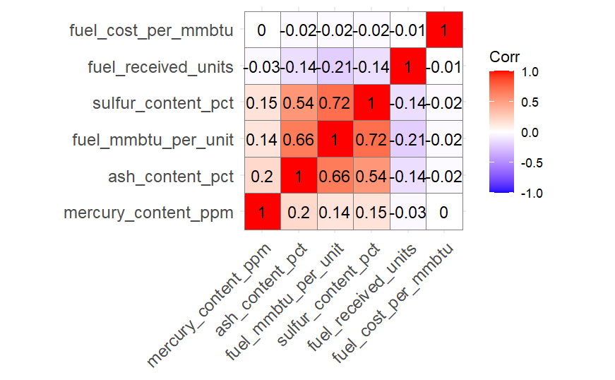

```r
#Looking at the Correlation between Variables.
corr_matrix <- cor(Normalized_Data)
ggcorrplot(corr_matrix, outline.color = "grey50", lab = TRUE, hc.order = TRUE, type = "full")
```

```r
data.pca <- princomp(corr_matrix)
summary(data.pca)
```

```
Importance of components:
                          Comp.1    Comp.2    Comp.3     Comp.4
Standard deviation     0.7772648 0.4083527 0.3768495 0.18664026
Proportion of Variance 0.6305096 0.1740302 0.1482141 0.03635501
Cumulative Proportion  0.6305096 0.8045398 0.9527539 0.98910895
                           Comp.5       Comp.6
Standard deviation     0.10215463 8.791168e-09
Proportion of Variance 0.01089105 8.065789e-17
Cumulative Proportion  1.00000000 1.000000e+00
```

*Sulphur_content and ash_content_pct are highly positively correlated with Fuel_mmbtu_per_unit. There no much significant negatively correlated fields.*

```r
data.pca$loadings[, 1:3]
```

```
                        Comp.1      Comp.2      Comp.3
fuel_received_units  0.4268177  0.48805140  0.42234746
fuel_mmbtu_per_unit -0.5476821 -0.02528103  0.16857375
sulfur_content_pct  -0.4927337  0.01228943  0.18978069
ash_content_pct     -0.4731486  0.04137523  0.06844589
mercury_content_ppm -0.0548836  0.28057131 -0.86636862
fuel_cost_per_mmbtu  0.2195511 -0.82497485 -0.04369632
```

*Six principal components have been generated (Comp.1 to Comp.6), which also correspond to the number of variables in the data. Each component explains a percentage of the total variance in the data set. In the Cumulative Proportion section, the first principal component explains almost 63% of the total variance. This implies that almost two-thirds of the data in the set of 6 variables can be represented by just the first principal component. The second one explains 17.4% of the total variance and the third one explains 14.8% of the total variance. The cumulative proportion of Comp.1, Comp.2 and Comp.3 explains nearly 95% of the total variance. This means that the first three principal components can accurately represent the data.*

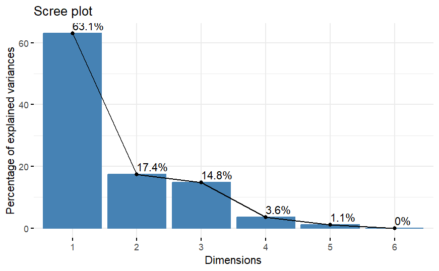

```r
fviz_eig(data.pca, addlabels = TRUE)
```

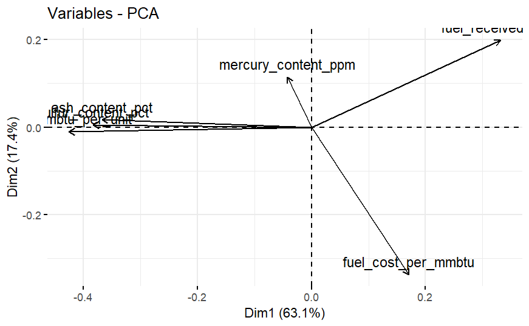

```r
# Graph of the variables
fviz_pca_var(data.pca, col.var = "black")
```

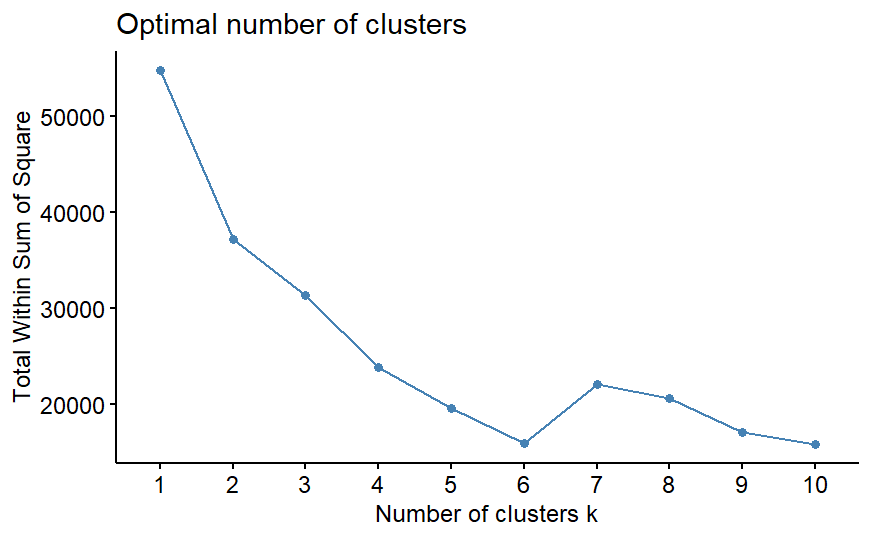

```r
#Elbow Method
Elbow_method <- fviz_nbclust(Normalized_Train,kmeans,method="wss")
Elbow_method
```

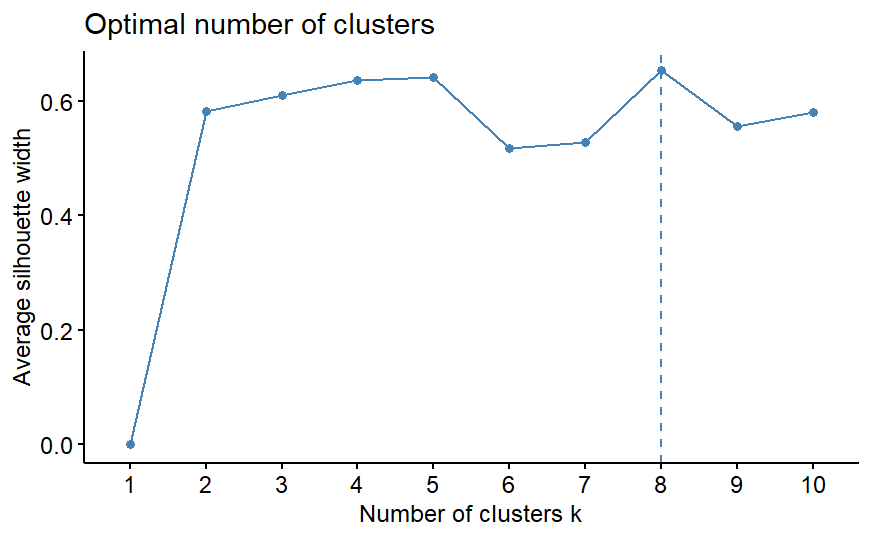

```r
#Silhouette Method
Silhouette <- fviz_nbclust(Normalized_Train,kmeans,method="silhouette")
Silhouette
```

*All the variables that are grouped together are positively correlated to each other. The higher the distance between the variable and the origin, the better represented that variable is. The variables that are negatively correlated are displayed to the opposite sides of the biplot’s origin.*

*Finding the Optimal K*

```r
#Using K Means -Silhouette
kmeans_clust <- kmeans(Normalized_Train,centers = 8,nstart=25)
pandoc.table(kmeans_clust$centers,style="grid", split.tables = Inf)
```

```
+---------------------+---------------------+--------------------+-----------------+---------------------+---------------------+
| fuel_received_units | fuel_mmbtu_per_unit | sulfur_content_pct | ash_content_pct | mercury_content_ppm | fuel_cost_per_mmbtu |
+=====================+=====================+====================+=================+=====================+=====================+
|       -0.3177       |       -0.3088       |      -0.3273       |     -0.5447     |       -0.1168       |       0.08907       |
+---------------------+---------------------+--------------------+-----------------+---------------------+---------------------+
|       -0.1453       |       -0.7948       |      -0.5176       |     -0.5454     |       -0.1168       |      -0.02138       |
+---------------------+---------------------+--------------------+-----------------+---------------------+---------------------+
|        2.58         |       -0.7946       |      -0.5176       |     -0.5454     |       -0.1168       |      -0.02804       |
+---------------------+---------------------+--------------------+-----------------+---------------------+---------------------+
|       -0.2462       |        1.185        |      0.07025       |     0.6753      |       0.1048        |      -0.03446       |
+---------------------+---------------------+--------------------+-----------------+---------------------+---------------------+
|       -0.326        |       -0.7942       |      -0.5176       |     -0.5454     |       -0.1168       |        49.88        |
+---------------------+---------------------+--------------------+-----------------+---------------------+---------------------+
|       -0.2965       |        1.202        |        1.93        |      2.807      |        12.6         |      -0.03051       |
+---------------------+---------------------+--------------------+-----------------+---------------------+---------------------+
|        7.955        |       -0.8008       |      -0.5176       |     -0.5454     |       -0.1168       |       -0.0264       |
+---------------------+---------------------+--------------------+-----------------+---------------------+---------------------+
|       -0.2772       |        1.43         |       2.281        |      1.418      |       0.03484       |      -0.03386       |
+---------------------+---------------------+--------------------+-----------------+---------------------+---------------------+
```

```r
kmeans_clust$size
```

```
[1]  830 4430  486 2130    3   33   64 1156
```

*The optimal value of k can be considered as k = 8 by using “Silhouette Method” as it is clear compared to Elbow Method.*

*Formulation of clusters with K=8*

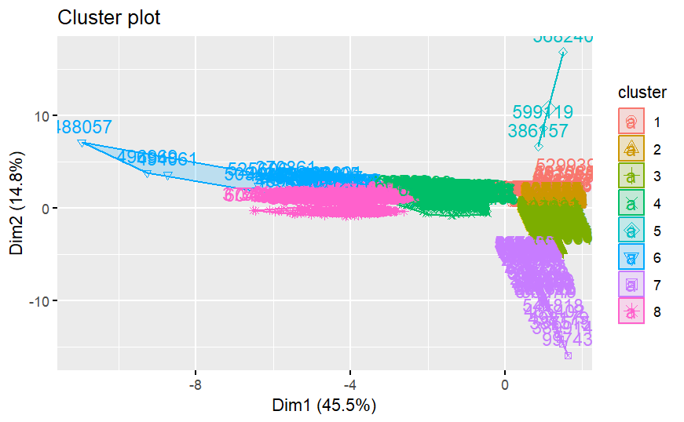

```r
cluster <- kmeans_clust$cluster
kmean_clustering <- cbind(Train_Data, cluster)

plot.cluster <- fviz_cluster(kmeans_clust, kmean_clustering[,-c(1:4)])
plot.cluster
```

```r
fuel_median <- kmean_clustering %>% group_by(cluster) %>%
summarise(median_cost = median(fuel_cost_per_mmbtu),
median_mmbtu = median(fuel_mmbtu_per_unit),
median_received_units = median(fuel_received_units),
median_sulfur = median(sulfur_content_pct)*0.01,
median_ash = median(ash_content_pct)*0.1,
median_mercury = median(mercury_content_ppm)*0.001)
fuel_median
```

| cluster | median_cost | median_mmbtu | median_received_units | median_sulfur | median_ash | median_mercury |
| --- | --- | --- | --- | --- | --- | --- |
| 1 | 11.582 | 5.8000 | 828.0 | 0.0000 | 0.00 | 0.00000 |
| 2 | 3.276 | 1.0270 | 22154.5 | 0.0000 | 0.00 | 0.00000 |
| 3 | 3.276 | 1.0300 | 2069810.0 | 0.0000 | 0.00 | 0.00000 |
| 4 | 2.643 | 18.0220 | 25185.0 | 0.0044 | 0.65 | 0.00000 |
| 5 | 6010.289 | 1.0370 | 27.0 | 0.0000 | 0.00 | 0.00000 |
| 6 | 3.276 | 22.2140 | 9532.0 | 0.0245 | 2.02 | 0.00038 |
| 7 | 3.276 | 1.0255 | 5364812.0 | 0.0000 | 0.00 | 0.00000 |
| 8 | 2.916 | 23.3515 | 18815.0 | 0.0283 | 0.91 | 0.00000 |

```r
fuel_clustering <- kmean_clustering %>% select(fuel_group_code, cluster) %>%
group_by(fuel_group_code, cluster) %>% count() %>% arrange(cluster)
fuel_clustering
```

| fuel_group_code | cluster | n |
| --- | --- | --- |
| coal | 1 | 2 |
| natural_gas | 1 | 11 |
| petroleum | 1 | 817 |
| natural_gas | 2 | 4403 |
| other_gas | 2 | 27 |
| natural_gas | 3 | 486 |
| coal | 4 | 2130 |
| natural_gas | 5 | 3 |
| coal | 6 | 33 |
| natural_gas | 7 | 60 |

[output cut: 3 more lines]

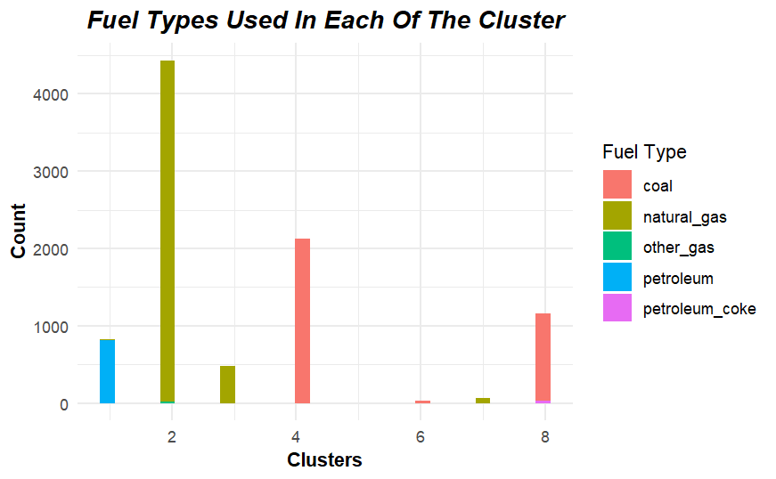

```r
Fuel_Plot <- ggplot(kmean_clustering) +
  aes(x = cluster, fill = fuel_group_code) +
  geom_histogram(bins = 30L) +
  scale_fill_hue(direction = 1) +
  labs(
    x = "Clusters",
    y = "Count",
    title = "Fuel Types Used In Each Of The Cluster",
    fill = "Fuel Type"
) +
  theme_minimal() +
  theme(
    plot.title = element_text(size = 14L,
    face = "bold.italic",
    hjust = 0.5),
    axis.title.y = element_text(face = "bold"),
    axis.title.x = element_text(face = "bold")
)


Fuel_Plot
```

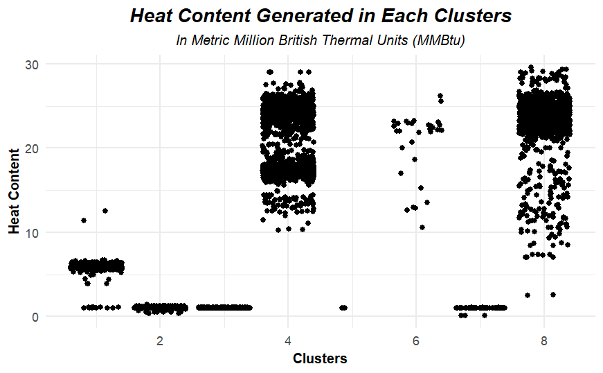

```r
Heat_Content_Plot <- ggplot(kmean_clustering) +
  aes(x = cluster, y = fuel_mmbtu_per_unit) +
  geom_jitter(size = 1.5) +
  labs(x = "Clusters",
    y = "Heat Content",
    title = "Heat Content Generated in Each Clusters",
    subtitle = "In Metric Million British Thermal Units (MMBtu)") +
  theme_minimal() +
  theme(plot.title = element_text(size = 14L,
    face = "bold.italic",
    hjust = 0.5),
    plot.subtitle = element_text(size = 10L,
    face = "italic",
    hjust = 0.5),
    axis.title.y = element_text(size = 10L,
    face = "bold"),
    axis.title.x = element_text(size = 10L,
    face = "bold"))
Heat_Content_Plot
```

```r
#Extra Credit - building the model

model<-lm(Fuel_Data_part$fuel_cost_per_mmbtu~.,data=Fuel_Data_part[,-c(2:4)])

summary(model)
```

[output not shown]

*Describing the cluster*

*Cluster 1: This cluster predominantly utilizes petroleum and natural gas as fuel sources for power generation. The median cost for generating power units with a heat content of 5.8 million metric British thermal units (MMBtu) is $11.6. This cluster generates a total of 828 units, and no impurities of Sulphur, mercury, or ash content are detected.*

*Cluster 2: Natural gas and other gases are the primary fuel sources in this cluster. The median cost for generating power units with a heat content of 1.0270 MMBtu is $3.276. This cluster generates approximately 22,154.5 units of power, and there are no impurities of Sulphur, mercury, or ash content.*

*Cluster 3: This cluster also relies on natural gas as its fuel source. The median cost for 1.0300 natural gas units is $3.276. It generates a significant amount of power with 2,069,810.0 units, which is the second highest among all clusters. No impurities are observed in this cluster.*

*Cluster 5: Natural gas is once again the fuel source in this cluster. The median cost for generating power units, which includes extreme outliers, is $6010.289 for a heat content of 1.0370. This cluster generates a minimal amount of power, with only 27.0 units, and no impurities are present.*

*Cluster 7: Among all the clusters, this cluster generates the highest number of gas units for power generation, amounting to 5,364,812.0 units. The fuel sources used are natural gas and other gases. The price for generating power units with a heat content of 1.0255 MMBtu is $3.276. No impurities are detected in this cluster.*

```r
#Extra Credit - building the model

model<-lm(Fuel_Data_part$fuel_cost_per_mmbtu~.,data=Fuel_Data_part[,-c(2:4)])

summary(model)
```

[output not shown]

```r
#Running the multiple linear regression model using just two variables which have greater statistical significance when compared to other variables
model_1 <- lm(fuel_cost_per_mmbtu~fuel_mmbtu_per_unit+fuel_received_units,data=Train_Data[,-c(2:4)])
summary(model_1)
```

```
Call:
lm(formula = fuel_cost_per_mmbtu ~ fuel_mmbtu_per_unit + fuel_received_units,
    data = Train_Data[, -c(2:4)])

Residuals:
    Min      1Q  Median      3Q     Max
  -11.7    -7.8    -4.0     0.1 11738.5

Coefficients:
                      Estimate Std. Error t value Pr(>|t|)
(Intercept)          1.224e+01  2.263e+00   5.410 6.47e-08 ***
fuel_mmbtu_per_unit -4.210e-01  1.636e-01  -2.573   0.0101 *
fuel_received_units -3.002e-06  2.151e-06  -1.396   0.1629
---
Signif. codes:  0 ‘***’ 0.001 ‘**’ 0.01 ‘*’ 0.05 ‘.’ 0.1 ‘ ’ 1

Residual standard error: 149.6 on 9129 degrees of freedom
Multiple R-squared:  0.0008073, Adjusted R-squared:  0.0005884
F-statistic: 3.688 on 2 and 9129 DF,  p-value: 0.02507
```

```r
model_predict <-predict(model_1,Test_Data,type="response")

summary(model_predict)
```

```
   Min. 1st Qu.  Median    Mean 3rd Qu.    Max.
-32.321   3.849   9.787   7.723  11.717  12.022
```

```r
Test_Predict <- cbind(Test_Data,model_predict)
```

```r
model_predict <-predict(model_1,Test_Data,type="response")

summary(model_predict)

Test_Predict <- cbind(Test_Data,model_predict)
```

[output not shown]

#The predicted value seems far away from the actual values, this can be referred by looking at the “Test_Predict” data frame.